# Project 1: Wrangling, Exploration, Visualization

SDS322E

## Data Wrangling, Exploration, Visualization

### Evelyn Stafford ebs797

#### Introduction

The data sets I have chosen for this project I have named `happiness` and `medals`. I found them on a website called Kaggle. Happiness gives data for 2021 on countries. It lists variables like their ladder score (measure of happiness), GDP per Capita, and Life expectancy. Medals also gives data for 2021 on countries, but this one focuses on the Olympics. It shows how many of each medal type each country has won, their total, and their ranking based on the total. I am very excited to analyze these two data sets together because I find the relationship between their variables interesting. I’m intrigued by the question “How does the state of a country affect their performance”.

```r
# read your datasets in here, e.g.
library(tidyr)
library(dplyr)
library(stringr)
happiness <- read.csv("world-happiness-report-2021.csv")
medals <- read.csv("Tokyo Medals 2021.csv")
```

### Tidying: Reshaping

Since my data sets were tidy already, I untidyed them and then made the following adjustments. First, I tidyed them again. Then, I kept only the variables I wanted to analyze. Finally, I renamed the ID variable in one of the data sets so that I could successfully join them.

```r
# your tidying code (if applicable; can also wait until
# wrangling section)

# untidying medals
library(tidyr)
medals <- medals %>% pivot_longer(2:5, names_to = "Medal Type",
    values_to = "Count")

# tidying medals
medals <- spread(medals, "Medal Type", "Count")
library(dplyr)
medals <- rename(medals, `Rank by Total Medals` = "Rank.By.Total")

# untidying happiness
happiness <- gather(happiness, "Information", "Result", 3:20)

# tidying happiness and keeping only the columns I want
happiness <- happiness %>% pivot_wider(names_from = "Information",
    values_from = "Result")
happiness <- happiness %>% select(Country.name, Regional.indicator,
    Ladder.score, Logged.GDP.per.capita, Healthy.life.expectancy)
happiness <- rename(happiness, Country = "Country.name")
```

#### Joining/Merging

```r
# your joining code

countries <- full_join(happiness, medals, by = "Country")
```

For this join I decided to do a full join. I wanted to see all of the countries no matter if they had a match or not.

```r
glimpse(happiness)
```

```
## Rows: 149
## Columns: 5
## $ Country                 <fct> Finland, Denmark, Switzerland, Iceland, Nethe…
## $ Regional.indicator      <fct> Western Europe, Western Europe, Western Europ…
## $ Ladder.score            <dbl> 7.842, 7.620, 7.571, 7.554, 7.464, 7.392, 7.3…
## $ Logged.GDP.per.capita   <dbl> 10.775, 10.933, 11.117, 10.878, 10.932, 11.05…
## $ Healthy.life.expectancy <dbl> 72.000, 72.700, 74.400, 73.000, 72.400, 73.30…
```

```r
length(unique(happiness$Country))
```

```
## [1] 149
```

```r
glimpse(medals)
```

```
## Rows: 93
## Columns: 6
## $ Country                <fct> Argentina, Armenia, Australia, Austria, Azerba…
## $ `Rank by Total Medals` <int> 60, 47, 6, 33, 33, 66, 77, 33, 33, 77, 77, 12,…
## $ Bronze.Medal           <int> 2, 2, 22, 5, 4, 0, 0, 3, 3, 0, 1, 8, 2, 1, 11,…
## $ Gold.Medal             <int> 0, 0, 17, 1, 0, 2, 0, 1, 3, 1, 0, 7, 3, 0, 7, …
## $ Silver.Medal           <int> 1, 2, 7, 1, 3, 0, 1, 3, 1, 0, 0, 6, 1, 0, 6, 4…
## $ Total                  <int> 3, 4, 46, 7, 7, 2, 1, 7, 7, 1, 1, 21, 6, 1, 24…
```

```r
length(unique(medals$Country))
```

```
## [1] 93
```

```r
glimpse(countries)
```

```
## Rows: 168
## Columns: 10
## $ Country                 <fct> Finland, Denmark, Switzerland, Iceland, Nethe…
## $ Regional.indicator      <fct> Western Europe, Western Europe, Western Europ…
## $ Ladder.score            <dbl> 7.842, 7.620, 7.571, 7.554, 7.464, 7.392, 7.3…
## $ Logged.GDP.per.capita   <dbl> 10.775, 10.933, 11.117, 10.878, 10.932, 11.05…
## $ Healthy.life.expectancy <dbl> 72.000, 72.700, 74.400, 73.000, 72.400, 73.30…
## $ `Rank by Total Medals`  <int> 66, 23, 20, NA, 9, 29, 26, NA, 13, 33, 6, 47,…
## $ Bronze.Medal            <int> 2, 4, 6, NA, 14, 2, 0, NA, 7, 5, 22, 2, 16, 1…
## $ Gold.Medal              <int> 0, 3, 3, NA, 10, 4, 3, NA, 7, 1, 17, 2, 10, 7…
## $ Silver.Medal            <int> 0, 4, 4, NA, 12, 2, 6, NA, 6, 1, 7, 0, 11, 6,…
## $ Total                   <int> 2, 11, 13, NA, 36, 8, 9, NA, 20, 7, 46, 4, 37…
```

```r
length(unique(countries$Country))
```

```
## [1] 168
```

```r
glimpse(inner_join(happiness, medals, by = "Country"))
```

```
## Rows: 74
## Columns: 10
## $ Country                 <fct> Finland, Denmark, Switzerland, Netherlands, N…
## $ Regional.indicator      <fct> Western Europe, Western Europe, Western Europ…
## $ Ladder.score            <dbl> 7.842, 7.620, 7.571, 7.464, 7.392, 7.363, 7.2…
## $ Logged.GDP.per.capita   <dbl> 10.775, 10.933, 11.117, 10.932, 11.053, 10.86…
## $ Healthy.life.expectancy <dbl> 72.000, 72.700, 74.400, 72.400, 73.300, 72.70…
## $ `Rank by Total Medals`  <int> 66, 23, 20, 9, 29, 26, 13, 33, 6, 47, 8, 11, …
## $ Bronze.Medal            <int> 2, 4, 6, 14, 2, 0, 7, 5, 22, 2, 16, 11, 2, 3,…
## $ Gold.Medal              <int> 0, 3, 3, 10, 4, 3, 7, 1, 17, 2, 10, 7, 2, 4, …
## $ Silver.Medal            <int> 0, 4, 4, 12, 2, 6, 6, 1, 7, 0, 11, 6, 0, 4, 1…
## $ Total                   <int> 2, 11, 13, 36, 8, 9, 20, 7, 46, 4, 37, 24, 4,…
```

```r
glimpse(anti_join(happiness, medals, by = "Country"))
```

```
## Rows: 75
## Columns: 5
## $ Country                 <fct> Iceland, Luxembourg, Costa Rica, United Kingd…
## $ Regional.indicator      <fct> Western Europe, Western Europe, Latin America…
## $ Ladder.score            <dbl> 7.554, 7.324, 7.069, 7.064, 6.951, 6.602, 6.5…
## $ Logged.GDP.per.capita   <dbl> 10.878, 11.647, 9.880, 10.707, 11.023, 10.674…
## $ Healthy.life.expectancy <dbl> 73.000, 72.600, 71.400, 72.500, 68.200, 72.20…
```

### Wrangling

For the chunk of wrangling below, I realized that certain notable countries had been duplicated instead of merged in my `countries` data set because they weren’t named exactly the same thing in each of the original data sets. Most notably the United States, Hong Kong, and China. This caused there to be two observations for each, one containing the information from `happiness` and the other containing the information from `medals`. I used mutate, str_replace_all, and select to create the cleaned up table `countriestab`. Here I have eliminated the duplicates.

```r
library(stringr)
dupes <- countries %>% mutate(`New Country Name` = (str_replace_all(Country,
    "United States of America", "United States")))
dupes <- dupes %>% mutate(`Country Name` = (str_replace_all(`New Country Name`,
    "People's Republic of China", "China")))
dupes <- dupes %>% mutate(Country = (str_replace_all(`Country Name`,
    "Hong Kong S.A.R. of China", "Hong Kong, China")))
dupes <- dupes[order(dupes$Country), ]
dupes <- dupes %>% fill(2:10, .direction = "downup")
countries <- dupes[-c(62, 28, 160), ] %>% select(Country, Regional.indicator,
    Ladder.score, Logged.GDP.per.capita, Healthy.life.expectancy,
    `Rank by Total Medals`, Gold.Medal, Silver.Medal, Bronze.Medal,
    Total)

library(gt)
countriestab <- countries %>% gt %>% tab_header(title = md("**Countries**"),
    subtitle = md("A cleaner verson of `countries` to omit notable duplicates"))

countriestab
```

**Countries**

A cleaner verson of `countries` to omit notable duplicates

| Country | Regional.indicator | Ladder.score | Logged.GDP.per.capita | Healthy.life.expectancy | Rank by Total Medals | Gold.Medal | Silver.Medal | Bronze.Medal | Total |
| --- | --- | --- | --- | --- | --- | --- | --- | --- | --- |
| Afghanistan | South Asia | 2.523 | 7.695 | 52.493 | 60 | 0 | 1 | 2 | 3 |
| Albania | Central and Eastern Europe | 5.117 | 9.520 | 68.999 | 60 | 0 | 1 | 2 | 3 |
| Algeria | Middle East and North Africa | 4.887 | 9.342 | 66.005 | 60 | 0 | 1 | 2 | 3 |
| Argentina | Latin America and Caribbean | 5.929 | 9.962 | 69.000 | 60 | 0 | 1 | 2 | 3 |
| Armenia | Commonwealth of Independent States | 5.283 | 9.487 | 67.055 | 47 | 0 | 2 | 2 | 4 |
| Australia | North America and ANZ | 7.183 | 10.796 | 73.900 | 6 | 17 | 7 | 22 | 46 |
| Austria | Western Europe | 7.268 | 10.906 | 73.300 | 33 | 1 | 1 | 5 | 7 |
| Azerbaijan | Commonwealth of Independent States | 5.171 | 9.569 | 65.656 | 33 | 0 | 3 | 4 | 7 |
| Bahamas | Commonwealth of Independent States | 5.171 | 9.569 | 65.656 | 66 | 2 | 0 | 0 | 2 |
| Bahrain | Middle East and North Africa | 6.647 | 10.669 | 69.495 | 77 | 0 | 1 | 0 | 1 |
| Bangladesh | South Asia | 5.025 | 8.454 | 64.800 | 77 | 0 | 1 | 0 | 1 |
| Belarus | Commonwealth of Independent States | 5.534 | 9.853 | 66.253 | 33 | 1 | 3 | 3 | 7 |
| Belgium | Western Europe | 6.834 | 10.823 | 72.199 | 33 | 3 | 1 | 3 | 7 |
| Benin | Sub-Saharan Africa | 5.045 | 8.087 | 54.713 | 33 | 3 | 1 | 3 | 7 |
| Bermuda | Sub-Saharan Africa | 5.045 | 8.087 | 54.713 | 77 | 1 | 0 | 0 | 1 |
| Bolivia | Latin America and Caribbean | 5.716 | 9.046 | 63.901 | 77 | 1 | 0 | 0 | 1 |
| Bosnia and Herzegovina | Central and Eastern Europe | 5.813 | 9.590 | 68.098 | 77 | 1 | 0 | 0 | 1 |
| Botswana | Sub-Saharan Africa | 3.467 | 9.782 | 59.269 | 77 | 0 | 0 | 1 | 1 |
| Brazil | Latin America and Caribbean | 6.330 | 9.577 | 66.601 | 12 | 7 | 6 | 8 | 21 |
| Bulgaria | Central and Eastern Europe | 5.266 | 10.016 | 67.000 | 39 | 3 | 1 | 2 | 6 |
| Burkina Faso | Sub-Saharan Africa | 4.834 | 7.678 | 54.151 | 77 | 0 | 0 | 1 | 1 |
| Burundi | Sub-Saharan Africa | 3.775 | 6.635 | 53.400 | 77 | 0 | 0 | 1 | 1 |
| Cambodia | Southeast Asia | 4.830 | 8.360 | 62.000 | 77 | 0 | 0 | 1 | 1 |
| Cameroon | Sub-Saharan Africa | 5.142 | 8.189 | 53.515 | 77 | 0 | 0 | 1 | 1 |
| Canada | North America and ANZ | 7.103 | 10.776 | 73.800 | 11 | 7 | 6 | 11 | 24 |
| Chad | Sub-Saharan Africa | 4.355 | 7.364 | 48.478 | 11 | 7 | 6 | 11 | 24 |
| Chile | Latin America and Caribbean | 6.172 | 10.071 | 70.000 | 11 | 7 | 6 | 11 | 24 |
| China | East Asia | 5.339 | 9.673 | 69.593 | 2 | 38 | 32 | 18 | 88 |
| Chinese Taipei | East Asia | 5.339 | 9.673 | 69.593 | 22 | 2 | 4 | 6 | 12 |
| Colombia | Latin America and Caribbean | 6.012 | 9.557 | 68.001 | 42 | 0 | 4 | 1 | 5 |

[output cut: 135 more lines]

In the chunk of wrangling below I set out to make a table with the averages of all the variables in `countries` grouped by region. I thought this would be interesting because it allows us to compare the relationship between variables. An interesting observation here is that average GDP, average happiness (or ladder score), and average life expectancy all seem to be correlated. That is, as GDP goes down so do happiness and life expectancy. This checks out logically, and gives some evidence to the fact that countries with higher GDPs seem to have relatively high values for other positive stats as well.

```r
averages <- countries %>% group_by(Regional.indicator) %>% summarise(distinc_countries = n_distinct(Country),
    avg_GDP = mean(Logged.GDP.per.capita), avg_ladder = mean(Ladder.score),
    avg_life_exp = mean(Healthy.life.expectancy), avg_gold = mean(Gold.Medal),
    avg_silver = mean(Silver.Medal), avg_bronze = mean(Bronze.Medal),
    avg_total = mean(Total))
averages <- arrange(averages, desc(avg_GDP))

avgtab <- averages %>% gt %>% tab_header(title = md("**Averages**"),
    subtitle = md("A look at the averages of the `countries` variables"))

avgtab
```

**Averages**

A look at the averages of the `countries` variables

| Regional.indicator | distinc_countries | avg_GDP | avg_ladder | avg_life_exp | avg_gold | avg_silver | avg_bronze | avg_total |
| --- | --- | --- | --- | --- | --- | --- | --- | --- |
| North America and ANZ | 4 | 10.809500 | 7.128500 | 72.32500 | 17.5000000 | 15.000000 | 18.250000 | 50.750000 |
| Western Europe | 29 | 10.762759 | 6.732310 | 72.96879 | 3.8275862 | 4.344828 | 5.482759 | 13.655172 |
| East Asia | 7 | 10.268429 | 5.743000 | 71.01514 | 9.8571429 | 7.857143 | 6.857143 | 24.571429 |
| Central and Eastern Europe | 18 | 10.115056 | 5.979056 | 68.47511 | 2.2222222 | 1.888889 | 2.111111 | 6.222222 |
| Middle East and North Africa | 17 | 9.666118 | 5.219765 | 65.60912 | 1.0000000 | 1.235294 | 2.411765 | 4.647059 |
| Southeast Asia | 9 | 9.421444 | 5.407556 | 64.88844 | 0.8888889 | 1.111111 | 1.444444 | 3.444444 |
| Commonwealth of Independent States | 13 | 9.414692 | 5.444231 | 65.05923 | 0.7692308 | 1.923077 | 2.923077 | 5.615385 |
| Latin America and Caribbean | 21 | 9.394286 | 5.963333 | 67.28195 | 3.8571429 | 3.952381 | 4.142857 | 11.952381 |
| South Asia | 7 | 8.682571 | 4.441857 | 62.68100 | 1.1428571 | 2.285714 | 2.142857 | 5.571429 |
| Sub-Saharan Africa | 40 | 8.068600 | 4.490600 | 56.11530 | 2.3000000 | 2.775000 | 3.000000 | 8.075000 |

In the chunk of wrangling below, I created a table that shows the relationship between rankings of GDP and total medal counts. It is very interesting to see the comparison between the two variables. As supported by the averages table, it seems that overall when the GDP is higher the total medal count is more likely to be high.

```r
rankings <- countries %>% mutate(`Rank by GDP` = dense_rank(desc(Logged.GDP.per.capita)))
rankings <- rankings %>% select(Country, Regional.indicator,
    `Rank by GDP`, `Rank by Total Medals`)
rankings <- arrange(rankings, desc(-(`Rank by GDP`)))

ranktab <- rankings %>% gt %>% tab_header(title = md("**Rankings**"),
    subtitle = md("A look at the relationship between rankings in my `countries`"))

ranktab
```

**Rankings**

A look at the relationship between rankings in my `countries`

| Country | Regional.indicator | Rank by GDP | Rank by Total Medals |
| --- | --- | --- | --- |
| Luxembourg | Western Europe | 1 | 77 |
| Singapore | Southeast Asia | 2 | 26 |
| Ireland | Western Europe | 3 | 47 |
| Islamic Republic of Iran | Western Europe | 3 | 33 |
| Switzerland | Western Europe | 4 | 20 |
| Syrian Arab Republic | Western Europe | 4 | 77 |
| United Arab Emirates | Middle East and North Africa | 5 | 16 |
| Norway | Western Europe | 6 | 29 |
| United States | North America and ANZ | 7 | 1 |
| Hong Kong, China | East Asia | 8 | 39 |
| Denmark | Western Europe | 9 | 23 |
| Netherlands | Western Europe | 10 | 9 |
| Austria | Western Europe | 11 | 33 |
| Iceland | Western Europe | 12 | 13 |
| Germany | Western Europe | 13 | 8 |
| Taiwan Province of China | East Asia | 14 | 77 |
| Sweden | Western Europe | 15 | 26 |
| Belgium | Western Europe | 16 | 33 |
| Kuwait | Middle East and North Africa | 17 | 77 |
| Australia | North America and ANZ | 18 | 6 |
| Canada | North America and ANZ | 19 | 11 |
| Finland | Western Europe | 20 | 66 |
| Saudi Arabia | Middle East and North Africa | 21 | 77 |
| United Kingdom | Western Europe | 22 | 16 |
| France | Western Europe | 23 | 10 |
| Malta | Western Europe | 24 | 66 |
| Bahrain | Middle East and North Africa | 25 | 77 |
| South Korea | East Asia | 26 | 60 |
| New Zealand | North America and ANZ | 27 | 13 |
| Italy | Western Europe | 28 | 7 |

[output cut: 135 more lines]

In the chunk of wrangling below I thought it would be interesting to look at the proportion of gold medals out of the total medals. Here we can see that as the number of total medals go up, it becomes more and more difficult to keep a high proportion of gold medals.

```r
propgold <- countries %>% filter(Gold.Medal > 0)
propgold <- propgold %>% mutate(`Proportion Gold` = Gold.Medal/Total) %>%
    select(Country, Regional.indicator, `Proportion Gold`, Total,
        `Rank by Total Medals`)
propgold <- arrange(propgold, desc(`Proportion Gold`))

proptab <- propgold %>% gt %>% tab_header(title = md("**Proportion Gold Medals**"),
    subtitle = md("A look at the relationship between the proportion of gold medals and the rank by total medals"))

proptab
```

**Proportion Gold Medals**

A look at the relationship between the proportion of gold medals and the rank by total medals

| Country | Regional.indicator | Proportion Gold | Total | Rank by Total Medals |
| --- | --- | --- | --- | --- |
| Bahamas | Commonwealth of Independent States | 1.00000000 | 2 | 66 |
| Bermuda | Sub-Saharan Africa | 1.00000000 | 1 | 77 |
| Bolivia | Latin America and Caribbean | 1.00000000 | 1 | 77 |
| Bosnia and Herzegovina | Central and Eastern Europe | 1.00000000 | 1 | 77 |
| Kosovo | Central and Eastern Europe | 1.00000000 | 2 | 66 |
| Morocco | Middle East and North Africa | 1.00000000 | 1 | 77 |
| Mozambique | Sub-Saharan Africa | 1.00000000 | 1 | 77 |
| Myanmar | Southeast Asia | 1.00000000 | 1 | 77 |
| Puerto Rico | Western Europe | 1.00000000 | 1 | 77 |
| Ecuador | Latin America and Caribbean | 0.66666667 | 3 | 60 |
| Qatar | Western Europe | 0.66666667 | 3 | 60 |
| Slovenia | Central and Eastern Europe | 0.60000000 | 5 | 42 |
| Uzbekistan | Commonwealth of Independent States | 0.60000000 | 5 | 42 |
| Bulgaria | Central and Eastern Europe | 0.50000000 | 6 | 39 |
| Estonia | Central and Eastern Europe | 0.50000000 | 2 | 66 |
| Fiji | Sub-Saharan Africa | 0.50000000 | 2 | 66 |
| Greece | Western Europe | 0.50000000 | 4 | 47 |
| Ireland | Western Europe | 0.50000000 | 4 | 47 |
| Israel | Middle East and North Africa | 0.50000000 | 4 | 47 |
| Latvia | Central and Eastern Europe | 0.50000000 | 2 | 66 |
| Lebanon | Middle East and North Africa | 0.50000000 | 2 | 66 |
| Lesotho | Sub-Saharan Africa | 0.50000000 | 2 | 66 |
| Liberia | Sub-Saharan Africa | 0.50000000 | 2 | 66 |
| Libya | Middle East and North Africa | 0.50000000 | 2 | 66 |
| Norway | Western Europe | 0.50000000 | 8 | 29 |
| Pakistan | South Asia | 0.50000000 | 8 | 29 |
| Palestinian Territories | Middle East and North Africa | 0.50000000 | 8 | 29 |
| Panama | Latin America and Caribbean | 0.50000000 | 8 | 29 |
| Paraguay | Latin America and Caribbean | 0.50000000 | 8 | 29 |
| Peru | Latin America and Caribbean | 0.50000000 | 8 | 29 |

[output cut: 76 more lines]

Finally, in this chunk of wrangling I had an idea to look at life expectancy compared to GDP. However, this time I wanted to look at it in terms of percentiles. This way I could see how the life expectancy changed according to what percentile a country was in. In order to get more detail, I pulled the mean, standard deviation, variation, minimum, and maximum life expectancies. Unfortunately, I could not get my if else statements to work properly, but I kept them in there so you could see my thought process.

```r
countries <- countries %>% mutate(Quantiles = (if (Logged.GDP.per.capita <=
    8.542) {
    "First"
} else if (Logged.GDP.per.capita <= 9.585) {
    "Second"
} else if (Logged.GDP.per.capita <= 10.421) {
    "Third"
} else if (Logged.GDP.per.capita <= 11.647) {
    "Fourth"
} else {
    NA
}))

lifeexp <- countries %>% group_by(Quantiles) %>% summarise(`Mean Life Expectancy` = mean(Healthy.life.expectancy),
    `Standard Deviation` = sd(Healthy.life.expectancy), Variation = var(Healthy.life.expectancy),
    Minimum = min(Healthy.life.expectancy), max(Healthy.life.expectancy))

lifetab <- lifeexp %>% gt %>% tab_header(title = md("**Life Expectancy**"),
    subtitle = md("A look at the relationship between life expectancy and GDP in my `countries`"))

lifetab
```

**Life Expectancy**

A look at the relationship between life expectancy and GDP in my `countries`

| Quantiles | Mean Life Expectancy | Standard Deviation | Variation | Minimum | max(Healthy.life.expectancy) |
| --- | --- | --- | --- | --- | --- |
| First | 65.31196 | 6.783601 | 46.01724 | 48.478 | 76.953 |

### Visualizing

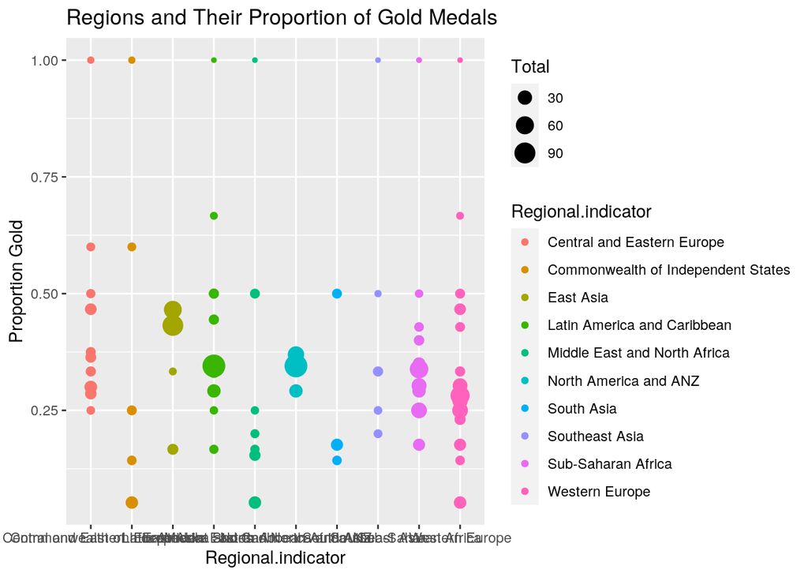

```r
# your plot 1
library(ggplot2)
plot1 <- ggplot(propgold, aes(Regional.indicator, `Proportion Gold`)) +
    geom_point(aes(size = Total, color = Regional.indicator))
print(plot1 + ggtitle("Regions and Their Proportion of Gold Medals"))
```

Here in plot 1 we are taking a look at the relationship between not only regions and their proportion of gold medals, but also the relationship between the proportion of gold medals and the number of total medals. It is really interesting to see here that across all regions, the only countries that have 100% gold medals have earned a very small amount of total medals. This makes sense logically because the more medals you win, the harder it gets to earn all gold.

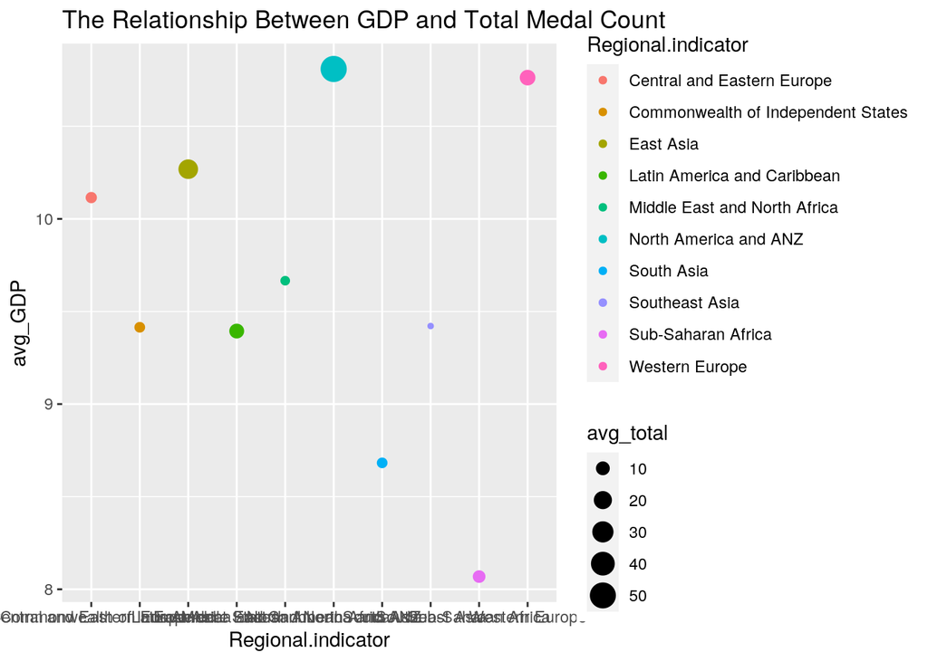

```r
# your plot 2
plot2 <- ggplot(averages, aes(Regional.indicator, avg_GDP)) +
    geom_point(aes(size = avg_total, color = Regional.indicator))
print(plot2 + ggtitle("The Relationship Between GDP and Total Medal Count"))
```

This plot shows the relationship between GDP and total medal count. The results of this visualization are the most interesting and important to note for me. It is quite easy to see that the largest bubbles on the graph are towards the top. This tells us that the most of the countries with the highest total medal count, also have a relatively high GDP. This is evidence towards the fact that having a higher GDP can lead to greater success at the olympics.

```r
# your plot 3
```

[output not shown]